# **Factors Affecting Loans at various states in the US**

## **Data Investigation**

#### I want to look at the factors or features that had an effect on the amount loaned out. I also want to know the various people who were most likely to default a loan payment

## **Dataset Overview**

#### This ProsperLoan data set contains 113,937 loans with 81 variables on each loan

#### For simplicity of the visualization I have looked at only few variables. The main dataframe was broken down into various datasets through the projects for simplicity and for easy analysis

### **What is/are the main feature(s) of interest in your dataset?**

I am interested in knowing what type of people default loans. And the correlation among some series

### **What percentage of Applicants defaulted payment**

```
0    98.838826
1     1.161174
Name: did_they_default, dtype: float64
```

Observation - We can see from above that 1.16% of lenders defaulted payment, this shows that majority of the borrowers are not defaulters

### **Distribution of borrowers credit ratings**

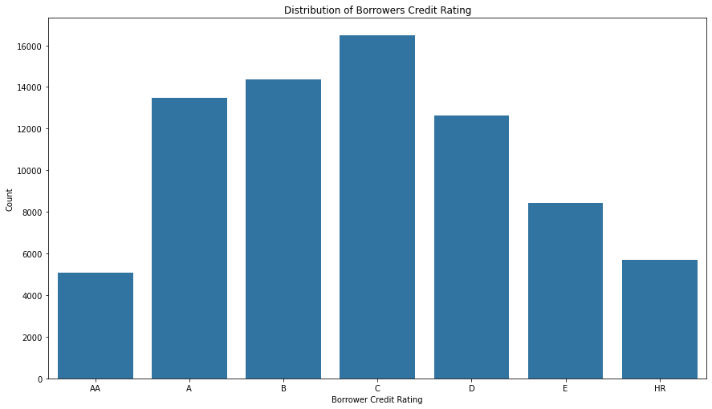

Observation - We can see that loans are widely spread across mid/average credit ratings, and shows that highly rated and poorly rated loans are not so often disbursed to loan applicants.

**Nb: AA - highly rated loans and keeps reducing till HR - poorly rated loans(or popularly known as subprime loans)**

### **Distribution of Defaulters borrowers credit ratings**

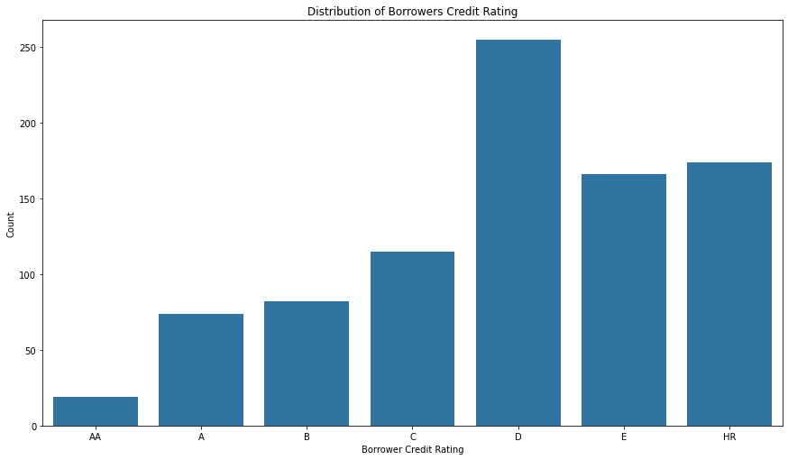

#### Observation

This shows that the majority of the loans distributed out to the defaulters are usually subprime loans (low quality) from grade C and above, this should be checked as a reason could be that most defaulters already have a low credit default score before they applied for the loans.

### **Which state defaulted the most with the Loans?**

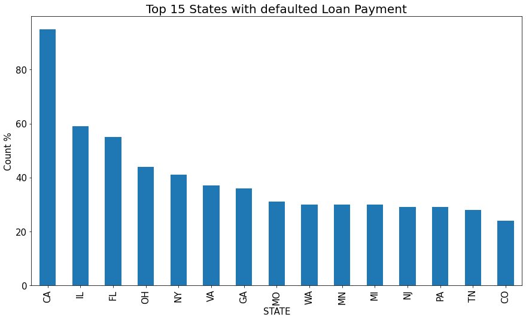

Observation - From the above, we can clearly see that the state with the most default as regards loan payment is California(CA)

### **Which state is most likely to default payment?**

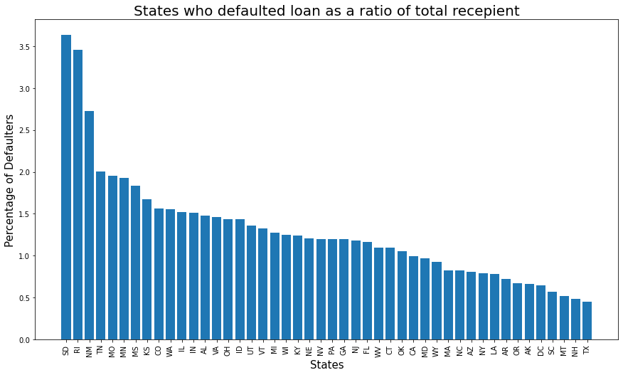

### New Observation

Contrary to what was discovered earlier from the 'Which state defaulted the most with the Loans?' graph. where 'CA' had the highest number of defaulters, we can see from the plot of the relative proportion of defaulter to loanees shown above that the earlier plot occured only due to 'CA' high number of loan recepients. A new plot shown above done based on the ratio of deafuters to the ratio of loan recepients can clearly show that although CA was very hgh it was not likely for a loan recepient in CA to deafult as they had a ratio less than 1,

Although states SD and RI were not in the first plot(ie top 15 in number of defaulters), their loan receipients were the most likely to default with a ratio above 3 for both.

#### Conclusion

A survey into the top 3 states should be made into checking why their relative proportion for defaulters is that high, lenders might want to look into this.

### **What was the majority of the loans used for?**

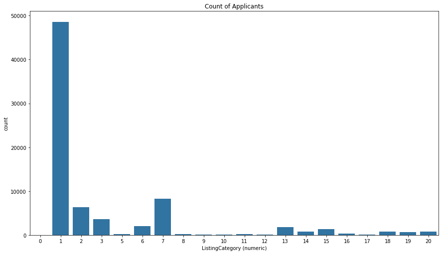

#### The category of the listing that the borrower selected when posting their listing:

0 - Not Available, 1 - Debt Consolidation, 2 - Home Improvement, 3 - Business, 4 - Personal Loan, 5 - Student Use, 6 - Auto, 7- Other, 8 - Baby&Adoption, 9 - Boat, 10 - Cosmetic Procedure 11 - Engagement Ring, 12 - Green Loans, 13 - Household Expenses, 14 - Large Purchases, 15 - Medical/Dental, 16 - Motorcycle, 17 - RV, 18 - Taxes, 19 - Vacation, 20 - Wedding Loans

##### Observation

With that explained, Debt consolidation had the highest purpose of loan followed by others and to complete the top 3 was home improvement... We might also want to look at why existing debtors are being giving so much loans just to repay existing debts (entering debt to pay for debts), financial institutions might want to look into this as it could be a ticking time bomb for them if the defaulters eventually refuse to pay

### **Variation of amount loaned out across various Income ranges.**

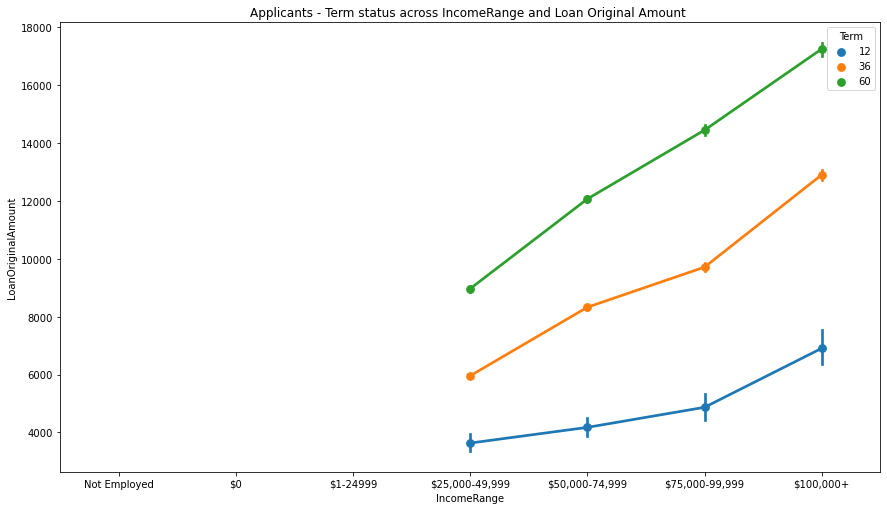

#### Observation

We can notice a positive correlation/relationship between income range and loan original Amount. People with the highest income borrowed the highest amount of money(or were borrowed the most) and those within the lowest range borrowed the lowest(or were not as privy as higher income range bands) and this trend can be seen across all the various terms of loan maturity

## **Summary and Observations**

All null values were removed for easy analysis

Not all applicants are emloyed

For defaulters, majority of the loan types given to them fall under the category of poorly rated loans, with only very few of them given highly rated loans.

The major reason for loan collection by most of the applicants was for "Debt Consolidation" by a great amount, this might want to be looked at.